# GeoData and Spatial Data Analysis with R

Edzer Pebesma

Program:

- 10:00 AM GeoData and Spatial Data Analysis with R (Part I)
- 12:00 PM Short Break
- 12:15 PM GeoData and Spatial Data Analysis with R (Part II)
- 02:15 PM end

Each full hour will have 45 minutes lecturing, followed by 15 mins Q&A.

# Context

- **Why “GeoData and Spatial Data”?** Because the organisation chose that title for me. I consider “GeoData” and “Spatial Data” as identical. “Geo” refers to “Earth”, so some spatial data, e.g. astronomic images or images taken through microscopes or MRT scans are less Earth-bound, and would be better described as “Spatial Data”.
- **Why “Data Analysis?”** Because this is a summer school on Data Science.
- **Why with R?** Because R is an open source environment **made for data analysis and graphics** that **runs on all platforms**. If we’d use a closed source environment, we’d miss the opportunity to reproduce and scrutinize computations and fail to meet the *science* goal of *Data Science*; if we’d use a general purpose programming language we would (more) easily end up in a package installation hell.
- **Why me?** I have been involved in R, and development of R-Spatial packages, for around 20 years, teach this subject on a regular basis, and recently finished the draft of the book [Spatial Data Science (with applications in R)](https://r-spatial.org/book).

## How to use these slides?

These slides were created with R and the R package `rmarkdown`. The source of these slides is an R-markdown document that can be loaded in R, and *executed* there (just like a Jupyter notebook, but simpler). To do this, take the following steps:

1. Go to the [GitHub page](https://github.com/edzer/hertie-school) of this course
2. Click on the file `slides.Rmd`
3. Click on the “Raw” tab
4. Right-click on that page, “save as”, and save it to a local copy of `slides.Rmd`
5. Click (or double-click) on this file, and RStudio should open it, showing the file
6. In RStudio, click “knit” to recreate the entire rendered document, which *runs all the R chunks*
7. For running individual R chunks, (notebook “cells”), use the arrows “Run all chunks above”, after which you can use “Run current chunk”

## What to expect?

10-11: Spatial data and geometries

- What is so special about spatial data?
- How can we represent spatial data in R?
- What does a coordinate mean?
- What does *coordinate reference system* mean?
- Geometries, measures, predicates, transformers
- Q&A

11-12: Attributes

- Support, aggregates
- `gapminder` example

12:15-13:15: Data cubes, large datasets

- `gapminder` data cube
- raster data
- raster time series
- image data cubes, image collections

13:15-14:15: Models

- point patterns
- geostatistical data
- lattice data

# Spatial data and geometries

## What is so special about spatial data?

## How can we represent spatial data in R?

## What does a coordinate mean?

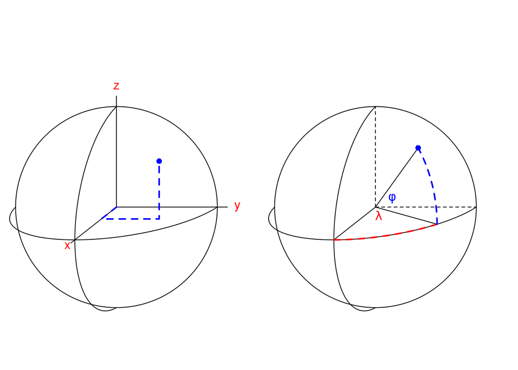

## What does *coordinate reference system* mean?

## Geometries, measures, predicates, transformers

# Attributes

## `gapminder` example

From the help of `gapminder` in package `gapminder` (by Jenny Bryan) “by continent, which country experienced the sharpest 5-year drop in life expectancy and what was the drop?”

```r
library(dplyr)
library(gapminder)
gapminder |>
   group_by(continent, country) |>
   select(country, year, continent, lifeExp) |>
   mutate(le_delta = lifeExp - lag(lifeExp)) |>
   summarize(worst_le_delta = min(le_delta, na.rm = TRUE)) |>
   filter(min_rank(worst_le_delta) < 2) |>
   arrange(worst_le_delta)
## `summarise()` has grouped output by 'continent'. You can override using the `.groups` argument.
## # A tibble: 5 x 3
## # Groups:   continent [5]
##   continent country     worst_le_delta
##   <fct>     <fct>                <dbl>
## 1 Africa    Rwanda             -20.4
## 2 Asia      Cambodia            -9.10
## 3 Americas  El Salvador         -1.51
## 4 Europe    Montenegro          -1.46
## 5 Oceania   Australia            0.170
```

Now, can we show a map of yearly changes in life expectancy?

Step 1: match the table to country geometries:

```r
library(rnaturalearth)
library(sf)
## Linking to GEOS 3.9.0, GDAL 3.2.1, PROJ 7.2.1
ne = ne_countries(returnclass = "sf")
# Try to match country names:
m = match(gapminder$country, ne$admin)
(u = unique(gapminder$country[is.na(m)]))
```

```
##  [1] Bahrain               Comoros               Congo, Dem. Rep.
##  [4] Congo, Rep.           Cote d'Ivoire         Guinea-Bissau
##  [7] Hong Kong, China      Korea, Dem. Rep.      Korea, Rep.
## [10] Mauritius             Reunion               Sao Tome and Principe
## [13] Serbia                Singapore             Slovak Republic
## [16] Tanzania              United States         West Bank and Gaza
## [19] Yemen, Rep.
## 142 Levels: Afghanistan Albania Algeria Angola Argentina Australia ... Zimbabwe
```

So this is pretty ugly. We can solve it the hard way, manually sorting out:

```r
n = as.character(ne$admin)
(conv = tribble(
        ~old, ~new,
        u[3], n[34],
        u[4], n[35],
        u[5], n[32],
        u[6], n[63],
        u[8], n[130],
        u[9], n[88],
        u[13], n[148],
        u[15], n[150],
        u[16], n[165],
        u[17], n[169],
        u[19], n[174]
))
```

```
## # A tibble: 11 x 2
##    old              new
##    <fct>            <chr>
##  1 Congo, Dem. Rep. Democratic Republic of the Congo
##  2 Congo, Rep.      Republic of Congo
##  3 Cote d'Ivoire    Ivory Coast
##  4 Guinea-Bissau    Guinea Bissau
##  5 Korea, Dem. Rep. North Korea
##  6 Korea, Rep.      South Korea
##  7 Serbia           Republic of Serbia
##  8 Slovak Republic  Slovakia
##  9 Tanzania         United Republic of Tanzania
## 10 United States    United States of America
## 11 Yemen, Rep.      Yemen
```

```r
library(stringr)
repl = conv$new
names(repl) = conv$old
gapminder$ncountry =
  str_replace_all(gapminder$country, repl)
m = match(gapminder$ncountry, ne$admin)
(un = unique(gapminder$country[is.na(m)]))
```

```
## [1] Bahrain               Comoros               Hong Kong, China
## [4] Mauritius             Reunion               Sao Tome and Principe
## [7] Singapore             West Bank and Gaza
## 142 Levels: Afghanistan Albania Algeria Angola Argentina Australia ... Zimbabwe
```

reducing the number of unmatched countries from 19 to 8.

Now we can do the big trick, and add a geometry column to `gapminder`:

```r
gapminder_sf = st_sf(gapminder, geometry = ne$geometry[m])
gapminder_sf$geometry
## Geometry set for 1704 features  (with 96 geometries empty)
## Geometry type: MULTIPOLYGON
## Dimension:     XY
## Bounding box:  xmin: -171.7911 ymin: -55.61183 xmax: 178.5171 ymax: 83.23324
## CRS:           +proj=longlat +datum=WGS84 +no_defs +ellps=WGS84 +towgs84=0,0,0
## First 5 geometries:
## MULTIPOLYGON (((61.21082 35.65007, 62.23065 35....
## MULTIPOLYGON (((61.21082 35.65007, 62.23065 35....
## MULTIPOLYGON (((61.21082 35.65007, 62.23065 35....
## MULTIPOLYGON (((61.21082 35.65007, 62.23065 35....
## MULTIPOLYGON (((61.21082 35.65007, 62.23065 35....
sum(is.na(m))
```

```
## [1] 96
```

We see that the `NA` values in `m` have been filled with empty geometries. Let’s look at the geometries:

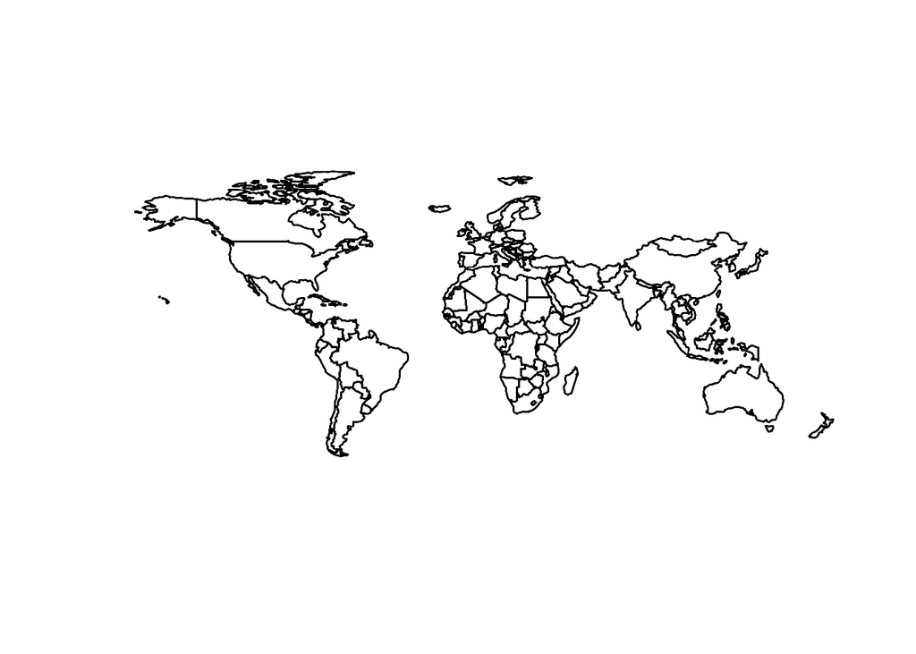

```r
st_geometry(gapminder_sf) |> plot()
```

Oops! We didn’t see that from the table above! Also the question didn’t mention “of all countries with complete time series”…

The help from `gapminder` (can you find that?) says: “The supplemental data frame ‘gapminder_unfiltered’ was not filtered on ‘year’ or for complete data and has 3313 rows.” Maybe we should use that?

```r
gapminder_unfiltered$ncountry =
  str_replace_all(gapminder_unfiltered$country, repl)
m = match(gapminder_unfiltered$ncountry, ne$admin)
(un = unique(gapminder_unfiltered$country[is.na(m)]))
```

```
##  [1] Aruba                 Bahamas               Bahrain
##  [4] Barbados              Cape Verde            Comoros
##  [7] French Guiana         French Polynesia      Grenada
## [10] Guadeloupe            Hong Kong, China      Macao, China
## [13] Maldives              Malta                 Martinique
## [16] Mauritius             Micronesia, Fed. Sts. Netherlands Antilles
## [19] Reunion               Samoa                 Sao Tome and Principe
## [22] Singapore             Timor-Leste           Tonga
## [25] West Bank and Gaza
## 187 Levels: Afghanistan Albania Algeria Angola Argentina Armenia ... Zimbabwe
```

```r
gapminder_u_sf = st_sf(gapminder_unfiltered, geometry = ne$geometry[m])
gapminder_u_sf$geometry
## Geometry set for 3313 features  (with 215 geometries empty)
## Geometry type: MULTIPOLYGON
## Dimension:     XY
## Bounding box:  xmin: -180 ymin: -55.61183 xmax: 180 ymax: 83.23324
## CRS:           +proj=longlat +datum=WGS84 +no_defs +ellps=WGS84 +towgs84=0,0,0
## First 5 geometries:
## MULTIPOLYGON (((61.21082 35.65007, 62.23065 35....
## MULTIPOLYGON (((61.21082 35.65007, 62.23065 35....
## MULTIPOLYGON (((61.21082 35.65007, 62.23065 35....
## MULTIPOLYGON (((61.21082 35.65007, 62.23065 35....
## MULTIPOLYGON (((61.21082 35.65007, 62.23065 35....
sum(is.na(m))
```

```
## [1] 215
```

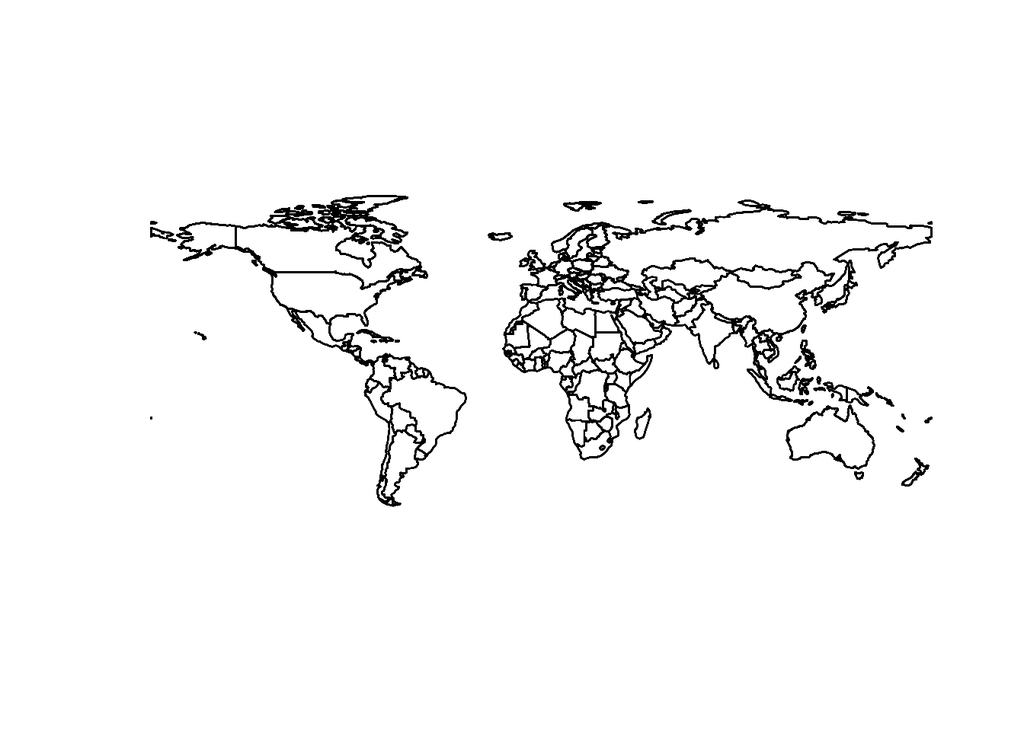

```r
st_geometry(gapminder_u_sf) |> plot()
```

looks much better. Which other countries are now included, but absent from `gapminder`?

```r
setdiff(unique(gapminder_unfiltered$ncountry), unique(gapminder$ncountry))
```

```
##  [1] "Armenia"               "Aruba"                 "Azerbaijan"
##  [4] "Bahamas"               "Barbados"              "Belarus"
##  [7] "Belize"                "Bhutan"                "Brunei"
## [10] "Cape Verde"            "Cyprus"                "Estonia"
## [13] "Fiji"                  "French Guiana"         "French Polynesia"
## [16] "Georgia"               "Grenada"               "Guadeloupe"
## [19] "Guyana"                "Kazakhstan"            "Latvia"
## [22] "Lithuania"             "Luxembourg"            "Macao, China"
## [25] "Maldives"              "Malta"                 "Martinique"
## [28] "Micronesia, Fed. Sts." "Moldova"               "Netherlands Antilles"
## [31] "New Caledonia"         "Papua New Guinea"      "Qatar"
## [34] "Russia"                "Samoa"                 "Solomon Islands"
## [37] "Suriname"              "Tajikistan"            "Timor-Leste"
## [40] "Tonga"                 "Turkmenistan"          "Ukraine"
## [43] "United Arab Emirates"  "Uzbekistan"            "Vanuatu"
```

We could now, for instance, create a map for the last measured year:

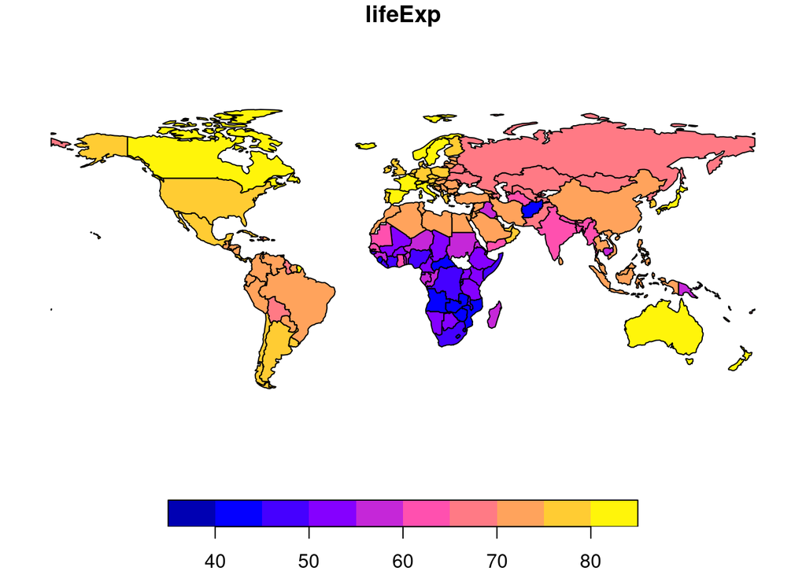

```r
gapminder_u_sf |>
        filter(year == 2007) |>
        select(lifeExp) |>
        plot()
```

where South Sudan appears to be missing (it gained independence in 2011).

Assessing missing-ness from plotting is a good check to find big ones (Russia), but not at all sufficient, since many countries are small. How many countries go invisible on a plot like the one above? Note that we plot country borders with thin lines (one pixel). Suppose that for a country to be visible with color it must span at least, say 3 x 3 pixels. We can obtain the device size in pixels by

```r
dev.size("px")
```

and let’s say it is 1000 by 1000. Then, the size of a single pixel (when we do not have margins around the plot) at the equator is roughly

```r
library(units)
## udunits database from /usr/share/xml/udunits/udunits2.xml
(pix_size = 2 * pi * set_units(s2::s2_earth_radius_meters(), m) / 1000)
## 40030.24 [m]
```

and the number of the Natural Earth countries with an area smaller than 9 equator-pixels is

```r
a = st_make_valid(ne) |> # the Natural Earth dataset is invalid on the sphere
    st_area() |>
    na.omit()
sum(a < 9 * pix_size^2)
```

```
## [1] 15
```